# Exploring the BRFSS data

Wayne Yang - waynejeyang@gmail.com

## Setup

Loading required packages and data.

### Load packages

```r
library(ggplot2)
library(dplyr)
```

### Load data

```r
load("/Users/wayneyang/Desktop/brfss2013.RData")
```

## Part 1: Data

The Behavioral Risk Factor Surveillance System (BRFSS) is a collaborative project amongst all the states in the United States and participating US territories and the Centers for Disease Control and Prevention. BRFSS is an ongoing surveillance system designed to measure behavioral risk factors for the non-institutionalized adult population (18 years of age and older) residing in the US. Its objective is to collect uniform, state-specific data on preventive health practices and risk behaviors that are linked to chronic diseases, injuries, and preventable infectious diseases that affect the adult population.

The BRFSS is an observational study and not an experimental one with random assignment - any relationship amongst variables will only indicate association and not causation.

The BRFSS collects data of the adult population residing in the U.S. Data is collected via landline telephone and cellular telephone surveys on a randomly selected adult in a household and adult participating uses a cellular device and resides in private residence or college housing. Data is also collected across 56 participating states participating in the BRFSS. According to this, adequate random sample is collected to ensure that the given data is generalizable to the larger U.S. population. However, even though this methodology attempts to be able to accurately portray and be generalized to the larger population, it also provides some bias towards particular individuals being selected for the survey.

Several biases include; - Only people with access to landline telephone and cellular telephone are surveyed - Not all selected adults respond to telephone surveys - Not all selected adults will be knowledgeable of the answers to the survey questions and thus may provide inaccurate responses

## Part 2: Research questions

**Research quesion 1:**

1. Is an individual’s education level and income level linked? Would their gender play a role in this linkage?

This question poses real life dilemmas it is commonly known that higher advanced degrees usually indicate different levels of income. Also, the variable of gender could also play a role in one’s education level and income level due to social norms, pay equity and discrimination.

Variables involved were: - educa: Education Level - income2: Income Level - sex: Reported Gender

**Research quesion 2:**

Post traumatic stress disorder is apparent within the veteran population. Being a veteran could be of relation with amount of sleep time had. Typical symptoms of PTSD is associated with a sleep disorder.

Variables involved were: - Sleptim1: How Much Time Do You Sleep - Veteran3: Are You A Veteran

**Research quesion 3:**

1. Does how often we undergo physical activity show any association with our general health? Also, would being overweight/obese also influence general health?

Physical activity is often linked with ones general health as well as whether one is obese/overweight. Plotting the different physical activity level of different groups with their respective general health should amount to adequate difference between the groups general health. We can also explore the obese vs non-obese groups of people as another variable to the plot.

Variables involved were: - Genhlth: General Health - _pacat1: Physical Activity Categories - _rfbmi5: Overweight Or Obese Calculated Variable

## Part 3: Exploratory data analysis

**Research quesion 1:**

Research Question 1: Is an individual’s education level and income level linked? Would their gender play a role in this linkage?

The first research question looks into the respondent’s education level as well as their respective income level in attempt to visualize these variables together. We then add the variable of gender to also see whether their would be a visual difference between male and female.

We first viewed the summary of each of the variables. (Note that there are NA values within all three summaries of each variable) We can see that there are 6 total categories within the education variable, 8 total categories within the income variable and final two within the sex variable (male and female)

```r
summary(brfss2013$educa)
```

```
##                   Never attended school or only kindergarten
##                                                          677
##                              Grades 1 through 8 (Elementary)
##                                                        13395
##                        Grades 9 though 11 (Some high school)
##                                                        28141
##                       Grade 12 or GED (High school graduate)
##                                                       142971
## College 1 year to 3 years (Some college or technical school)
##                                                       134197
##                   College 4 years or more (College graduate)
##                                                       170120
##                                                         NA's
##                                                         2274
```

```r
summary(brfss2013$income2)
```

```
## Less than $10,000 Less than $15,000 Less than $20,000 Less than $25,000
##             25441             26794             34873             41732
## Less than $35,000 Less than $50,000 Less than $75,000   $75,000 or more
##             48867             61509             65231            115902
##              NA's
##             71426
```

```r
summary(brfss2013$sex)
```

```
##   Male Female   NA's
## 201313 290455      7
```

We then extracted and viewed the summary of the three variables combined in groups according to their count

```r
brfss2013 %>%
  group_by(educa,income2,sex) %>%
  summarise(count = n())
```

```
## # A tibble: 130 x 4
## # Groups:   educa, income2 [?]
##                                         educa           income2    sex
##                                        <fctr>            <fctr> <fctr>
##  1 Never attended school or only kindergarten Less than $10,000   Male
##  2 Never attended school or only kindergarten Less than $10,000 Female
##  3 Never attended school or only kindergarten Less than $15,000   Male
##  4 Never attended school or only kindergarten Less than $15,000 Female
##  5 Never attended school or only kindergarten Less than $20,000   Male
##  6 Never attended school or only kindergarten Less than $20,000 Female
##  7 Never attended school or only kindergarten Less than $25,000   Male
##  8 Never attended school or only kindergarten Less than $25,000 Female
##  9 Never attended school or only kindergarten Less than $35,000   Male
## 10 Never attended school or only kindergarten Less than $35,000 Female
## # ... with 120 more rows, and 1 more variables: count <int>
```

We then select these variables from the brfss2013 data set into a separate smaller data set only containing the three variables named rsq1 and omit all the NA. I dimmed rsq1 to ensure that we are only looking at the three variables as well as looked at the overall numerical summary in a table format.

```r
rsq1 <- select(brfss2013,educa,income2,sex) %>% na.omit()
dim(rsq1)
```

```
## [1] 419821      3
```

```r
table(rsq1)
```

```
## , , sex = Male
##
##                                                               income2
## educa                                                          Less than $10,000
##   Never attended school or only kindergarten                                  32
##   Grades 1 through 8 (Elementary)                                            881
##   Grades 9 though 11 (Some high school)                                     1381
##   Grade 12 or GED (High school graduate)                                    3017
##   College 1 year to 3 years (Some college or technical school)              1856
##   College 4 years or more (College graduate)                                1105
##                                                               income2
## educa                                                          Less than $15,000
##   Never attended school or only kindergarten                                  39
##   Grades 1 through 8 (Elementary)                                            876
##   Grades 9 though 11 (Some high school)                                     1309
##   Grade 12 or GED (High school graduate)                                    3534
##   College 1 year to 3 years (Some college or technical school)              2311
##   College 4 years or more (College graduate)                                1115
##                                                               income2
## educa                                                          Less than $20,000
##   Never attended school or only kindergarten                                  44
##   Grades 1 through 8 (Elementary)                                            950
##   Grades 9 though 11 (Some high school)                                     1593
##   Grade 12 or GED (High school graduate)                                    5058
##   College 1 year to 3 years (Some college or technical school)              3107
##   College 4 years or more (College graduate)                                1775
##                                                               income2
## educa                                                          Less than $25,000
##   Never attended school or only kindergarten                                  30
##   Grades 1 through 8 (Elementary)                                            749
##   Grades 9 though 11 (Some high school)                                     1506
##   Grade 12 or GED (High school graduate)                                    6485
##   College 1 year to 3 years (Some college or technical school)              4167
##   College 4 years or more (College graduate)                                2761
##                                                               income2
## educa                                                          Less than $35,000
##   Never attended school or only kindergarten                                  24
##   Grades 1 through 8 (Elementary)                                            619
##   Grades 9 though 11 (Some high school)                                     1379
##   Grade 12 or GED (High school graduate)                                    7722
```

[output cut: 78 more lines]

```
## educa                                                          Less than $75,000
##   Never attended school or only kindergarten                                  13
##   Grades 1 through 8 (Elementary)                                             69
##   Grades 9 though 11 (Some high school)                                      413
##   Grade 12 or GED (High school graduate)                                    7370
##   College 1 year to 3 years (Some college or technical school)             11222
##   College 4 years or more (College graduate)                               16723
##                                                               income2
## educa                                                          $75,000 or more
##   Never attended school or only kindergarten                                12
##   Grades 1 through 8 (Elementary)                                           91
##   Grades 9 though 11 (Some high school)                                    364
##   Grade 12 or GED (High school graduate)                                  6898
##   College 1 year to 3 years (Some college or technical school)           13768
##   College 4 years or more (College graduate)                             38186
```

Next, I decided to form a graphical visualization of the three variables using the geom_jitter function within the ggplot library. I placed the education level as the X axis and the reported incomes on the Y axis. We can then see the visualization and note the difference in the amount of jitter points within each section of the geom according to an individuals education level and reported income. Note how as we progress down the X axis (left to right) – more jitter points are located toward the higher reported income.

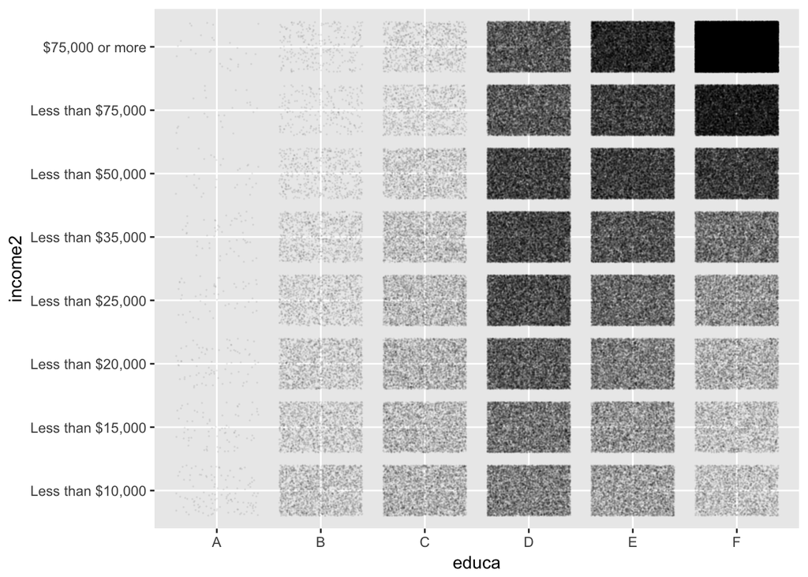

```r
plot1 <- ggplot(rsq1, aes(x = educa, y = income2))+ geom_jitter(size = 1/80, alpha = 1/20) + scale_x_discrete(labels = c('A','B','C','D','E','F'))
plot1
```

```r
#Note. A - Never attended school or only kindergarten
#B - Grades 1 through 8 (elementary)
#C - Grades 9 through 11 (Some high school)
#D - Grades 12 or GED (High school graduate)
#E - College 1 year to 3 years (Some college or technical school)
#F - College 4 years or more (College graduate)
```

Next, I added the variable of sex using the facet_grid function. This splits the geom into two separate visualizations (male and female). We can find the association between education level and reported income – specifically, a higher education level indicates a higher reported income due to the larger amount of jitter points in the indicated regions on the plot.

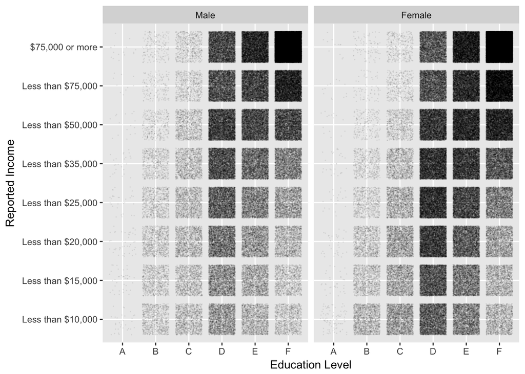

```r
plot1 <- plot1 + facet_grid(. ~ sex) + xlab("Education Level") + ylab("Reported Income")
plot1
```

**Research quesion 2:**

Research Question 2: Is a respondents amount of time slept related to whether that individual is a veteran?

First, I extracted the required variables (sleptim1 & veteran3) from the larger brfss2013 dataset, grouped and summarized them based on their count.

```r
brfss2013 %>%
  group_by(sleptim1,veteran3) %>%
  summarise(count = n())
```

```
## # A tibble: 66 x 3
## # Groups:   sleptim1 [?]
##    sleptim1 veteran3 count
##       <int>   <fctr> <int>
##  1        0       NA     1
##  2        1      Yes    30
##  3        1       No   198
##  4        2      Yes   183
##  5        2       No   886
##  6        2       NA     7
##  7        3      Yes   456
##  8        3       No  3027
##  9        3       NA    13
## 10        4      Yes  1975
## # ... with 56 more rows
```

I then selected the specific variables that I will be using into a smaller data set named rsq2 and omitted all the NA values. Following this I viewed a numerical summary of the data values that I will be looking at in a table format. Note how there are some abnormal values in the sleptim1 column. This will need to be addressed when visualizing the data.

```r
rsq2 <- select(brfss2013,sleptim1,veteran3) %>% na.omit()
table(rsq2)
```

```
##         veteran3
## sleptim1    Yes     No
##      1       30    198
##      2      183    886
##      3      456   3027
##      4     1975  12265
##      5     4060  29328
##      6    12762  93284
##      7    16462 125847
##      8    18359 122528
##      9     3546  20227
##      10    1870  10210
##      11     127    702
##      12     518   3147
##      13      17    181
##      14      66    381
##      15      45    322
##      16      46    322
##      17       5     30
##      18      25    139
##      19       1     12
##      20       9     55
##      21       0      3
##      22       1      9
##      23       1      3
##      24       1     34
##      450      1      0
```

Using geom_violin to visualise the data – I plotted rsq2 with veteran status on the x axis and time slept on the y axis. In addition, I used the ylim parameter of 3,11 to remove the abnormal values from the data set (e.g. 450 hour’s time slept of one respondent)

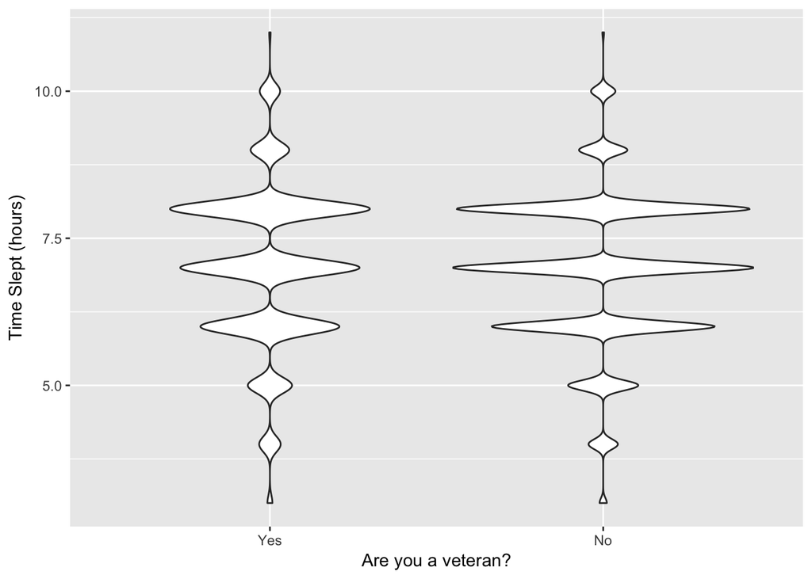

```r
plot2 <- ggplot(rsq2, aes(x = veteran3, y = sleptim1)) +
  geom_violin() +
  xlab("Are you a veteran?") +
  ylab ("Time Slept (hours)") +
  ylim(c(3,11))
plot2
```

**Research quesion 3:**

Research Question 3: Does how often we undergo physical activity show any association with our general health? Also, would being overweight/obese also influence general health?

Similar to the previous research question, I first extracted the required variables (genhtlh, X_pacat1, X_rfbmi5) from the larger brfss2013 dataset, grouped and summarized them based on their count. Following this, I selected the specific variables to place into a new smaller dataset named rsq3 and omitted all the NA values. Using the table() function I viewed a numerical summary of the data values that I will be looking at in a table format.

```r
brfss2013 %>%
  group_by(genhlth,X_pacat1,X_rfbmi5) %>%
  summarise(count = n())
```

```
## # A tibble: 90 x 4
## # Groups:   genhlth, X_pacat1 [?]
##      genhlth              X_pacat1 X_rfbmi5 count
##       <fctr>                <fctr>   <fctr> <int>
##  1 Excellent         Highly active       No 16665
##  2 Excellent         Highly active      Yes 13637
##  3 Excellent         Highly active       NA   881
##  4 Excellent                Active       No  7545
##  5 Excellent                Active      Yes  6803
##  6 Excellent                Active       NA   533
##  7 Excellent Insufficiently active       No  6103
##  8 Excellent Insufficiently active      Yes  6089
##  9 Excellent Insufficiently active       NA   565
## 10 Excellent              Inactive       No  4979
## # ... with 80 more rows
```

```r
rsq3 <- select(brfss2013,genhlth,X_rfbmi5,X_pacat1) %>% na.omit()
dim(rsq3)
```

```
## [1] 394838      3
```

```r
table(rsq3)
```

```
## , , X_pacat1 = Highly active
##
##            X_rfbmi5
## genhlth        No   Yes
##   Excellent 16665 13637
##   Very good 19159 29048
##   Good      11353 24767
##   Fair       3675  8481
##   Poor       1125  2204
##
## , , X_pacat1 = Active
##
##            X_rfbmi5
## genhlth        No   Yes
##   Excellent  7545  6803
##   Very good  9913 16257
##   Good       5372 14197
##   Fair       1638  4868
##   Poor        551  1299
##
## , , X_pacat1 = Insufficiently active
##
##            X_rfbmi5
## genhlth        No   Yes
##   Excellent  6103  6089
##   Very good  9253 17085
##   Good       5997 17053
##   Fair       2062  6955
##   Poor        849  2288
##
## , , X_pacat1 = Inactive
##
##            X_rfbmi5
## genhlth        No   Yes
##   Excellent  4979  6908
##   Very good  9312 19632
##   Good      10723 30475
##   Fair       6291 19776
##   Poor       4118 10333
```

As all of the variables are categorical data, I decided to use the geom_bar function for my data visualization method and use (position=”fill”) to scale the proportions of general health to 1 for a better representation. Note that I needed to rotate the x labels so that we are able to read the x labels.

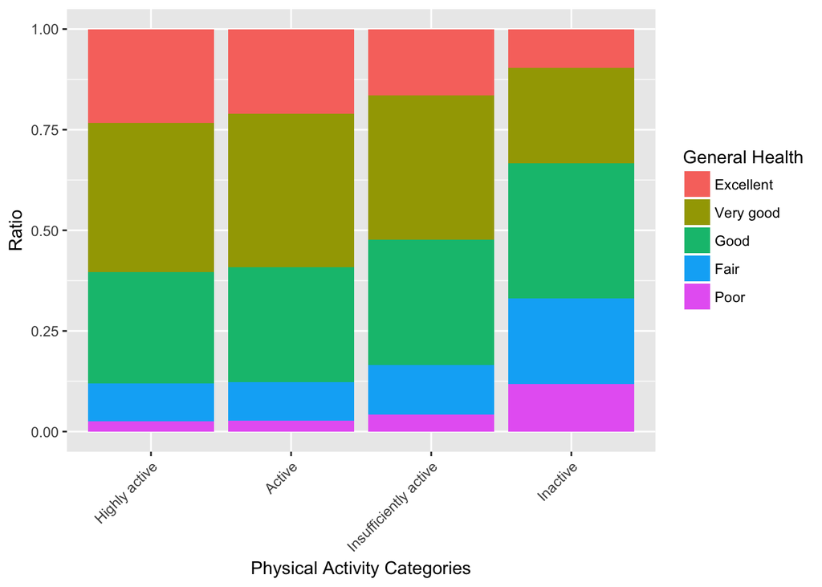

```r
plot3 <- ggplot(rsq3, aes(x = X_pacat1, fill = genhlth)) +
  geom_bar(position='fill') +
  xlab("Physical Activity Categories") +
  ylab("Ratio") +
  scale_fill_discrete(name="General Health") +
  theme(axis.text.x=element_text(angle=45, hjust=1))
plot3
```

Lastly I added the third variable of X_rfbmi5 which is a categorical variable that states whether the respondent was obese or not. This variable had data in a “yes” or “no” factor format, thus I changed it to “Not Obese (<25 bmi)” and “Obese (>25 bmi)” for a clearer visualization

```r
summary(rsq3$X_rfbmi5)
```

```
##     No    Yes
## 136683 258155
```

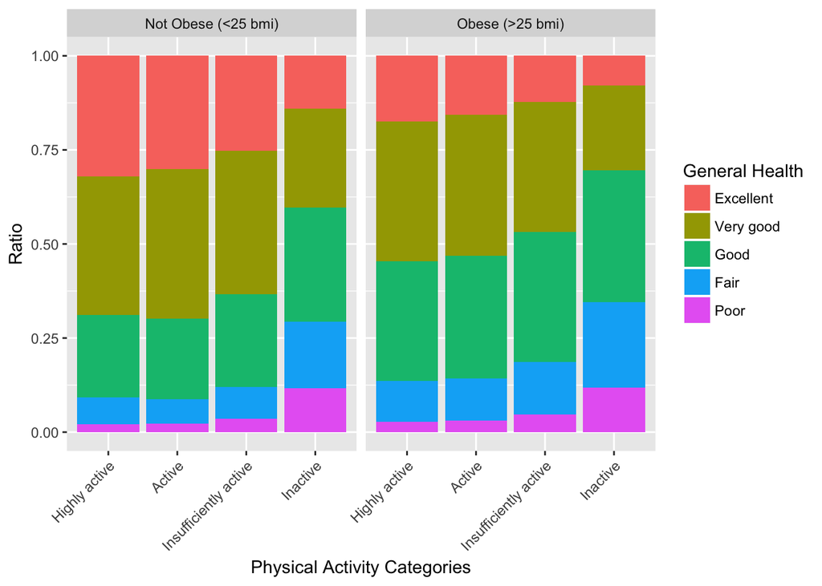

```r
levels(rsq3$X_rfbmi5) <- c("Not Obese (<25 bmi)","Obese (>25 bmi)")
plot3 <- plot3 +
  facet_grid(.~rsq3$X_rfbmi5)
  plot3
```

The above visualization indicates an association between the physical activity category that the respondent is in and their respective general health. The plot indicates that the group of people who are more active have a greater ratio of better general health. This means that being more physically active indicates better general health as well as vice versa. After the addition of the third variable using the fact_grid function – we find that there is also an association between whether the respondent was obese or not and their general health. The group who aren’t obese have a higher ratio of better general health across all physical activity categories.